# Example 3 - Scrape My Website

What if I want to scrape the computational notes on my own website? I need a for-loop to iterate over each page, and I’d like to end up with a data set containing the following for each page:

- title
- the text content.

First, I need to scrape the links to direct my for-loop where to go.

```r
library(rvest)
own_links_page <- read_html('https://christopherdishop.netlify.com/computational_notes/')
own_links <- html_nodes(own_links_page, '.title a') %>%
                            html_attr('href')

head(own_links)
```

```
## [1] "/computational_notes/methods_others/"
## [2] "/computational_notes/julia_cheatsheet/"
## [3] "/computational_notes/skeleton/"
## [4] "/computational_notes/sims_rccp/"
## [5] "/computational_notes/regression_composite/"
## [6] "/computational_notes/ma_compute/"
```

Now I have a vector of links directing me to relevant pages. Normally, the next step would be to use `read_html()` and specify one value within `own_links` to tell it where to go. That won’t work here because the links stored within `own_links` are relative, and `read_html()` cannot handle relative paths.

So, in the next step I will use Hadley’s `jump_to` function which can handle relative paths.

Start on the link homepage, then use the first value stored within `own_links` to navigate to the first web page I want to scrape.

```r
# jump_to() requires a html_session rather than read_html page

own_links_page <- html_session('https://christopherdishop.netlify.com/computational_notes/')

scrape_page1 <- own_links_page %>%
  jump_to(own_links[1])
```

Then, scrape the text within that post.

```r
html_node(scrape_page1, '.content.container p') %>% html_text
```

```
## [1] "I recently created my first slide deck using Garrick Aden-Buie’s awesome template called “Gentle Ggplot2.” You can find the presentation here and the source code on my GitHub page."
```

Cool, everything works for a single page. Now iterate over every page and store the results in a data frame.

```r
library(tidyverse)

df3 <- data.frame(
  'page_title' = c(rep('store', length(own_links))),
  'text' = c(rep('store', length(own_links)))

  )

df3 <- df3 %>%
  mutate_if(is.factor, as.character)

for(i in 1:length(own_links)){
  Sys.sleep(0.5)

  navigate_page <- own_links_page %>%
    jump_to(own_links[i])


  title <- gsub('/computational_notes/', '', own_links[i])
  title <- gsub('/', '', title)
  text <- html_node(navigate_page, '.content.container p') %>% html_text

  df3[i, 'page_title'] <- title
  df3[i, 'text'] <- text

}

head(df3)
```

```
##             page_title
## 1       methods_others
## 2     julia_cheatsheet
## 3             skeleton
## 4            sims_rccp
## 5 regression_composite
## 6           ma_compute
##                                                                                                                                                                                                                                                                                                          …
## 1                                                                                                                                                                                                           I recently created my first slide deck using Garrick Aden-Buie’s awesome template called “Gen…
## 2                                                                                                                                                                                                                                                                       I started using Julia for my comp…
## 3                                                                                                                                                                                              I recently created a course skeleton for a research methods or statistics course. The website allows you t…
## 4                                                                                                                                                                                                                                                                        Simulating dynamic processes is …
## 5 One way to think about regression is as a tool that takes a set of predictors and creates a weighted, linear composite that maximally correlates with the response variable. It finds a way to combine multiple predictors into a single thing, using regression weights, and the weights are chosen su…
## 6                                                                                                                                                                                                                                                                                                        …
```

Awesome. How about the sentiment across the various posts?

```r
library(sentimentr)
sent_df <- sentiment(df3$text)

library(ggplot2)
sent_df$title <- df3$page_title
sent_df <- sent_df %>%
  mutate(color = ifelse(sentiment < 0, 'negative', 'positive'))
```

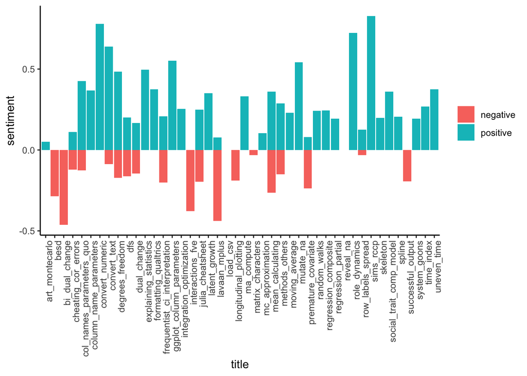

```r
ggplot(sent_df, aes(x = title, y = sentiment, fill = color)) +
  geom_bar(stat = 'identity') +
  theme_classic() +
  theme(axis.text.x = element_text(angle = 90, hjust = 1)) +
  theme(legend.title = element_blank())
```

Sentiment by post arranged by strength of sentiment.

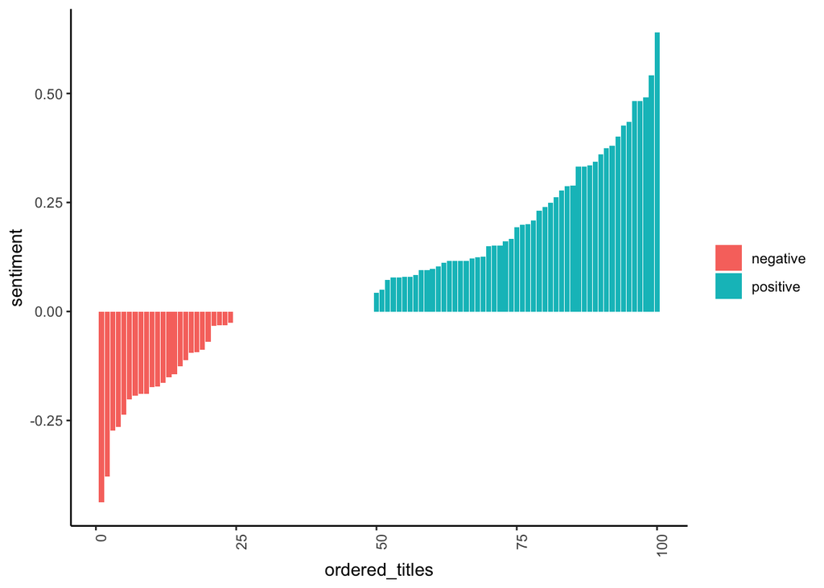

```r
sent_df %>%
  arrange(sentiment) %>%
  mutate(ordered_titles = 1:nrow(sent_df)) %>%
  ggplot(aes(x = ordered_titles, y = sentiment, fill = color)) +
  geom_bar(stat = 'identity') +
  theme_classic() +
  theme(axis.text.x = element_text(angle = 90, hjust = 1)) +
  theme(legend.title = element_blank())
```